# Principal Components Analysis

# Structure and latent variables

- Three primary uses for PCA
  - Reduced dimensionality = summarizing, simplifying multivariate patterns
  - Latent variables = variables that exist conceptually, but cannot be measured directly
  - Structure = patterns of inter-correlation
- All rely on finding new linear **axes** through the data
  - Constructed from the measured variables
  - Represent multivariate patterns across them

# A gentle introduction to PCA

at least, graphical and intuitive

- Lengths of leg bones, Bumpus data
  - Strongly correlated, r = 0.8
- What do the combination of two variables tell us that a single cannot?

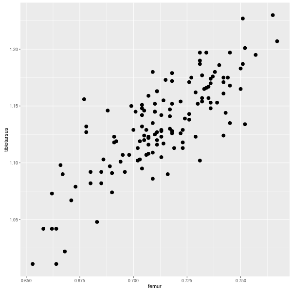

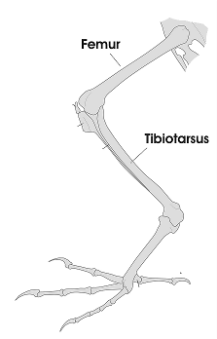

Placing a line through the data swarm

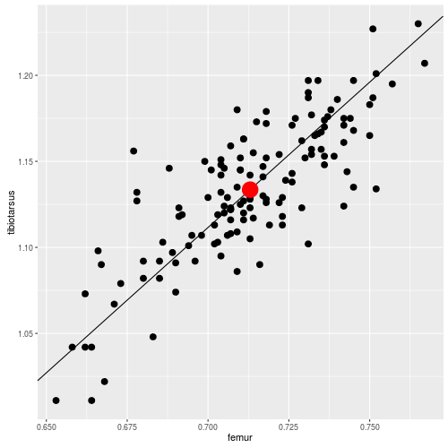

[figure not shown]

Placed to maximize variation along its length

Runs through the centroid

Line is the correlated part of femur and tibiotarsus

Called the principal component axis 1

Points are *scored* along the PCA axis

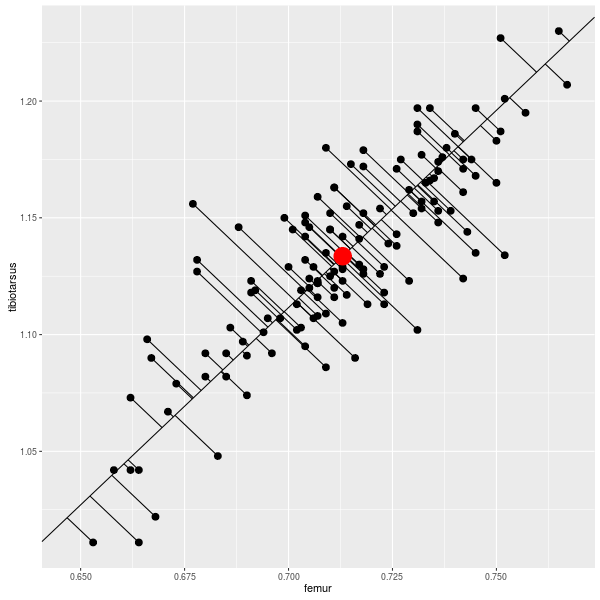

Perpendicularly project the points to the line, assign a numeric position

## PC1 indicates leg size

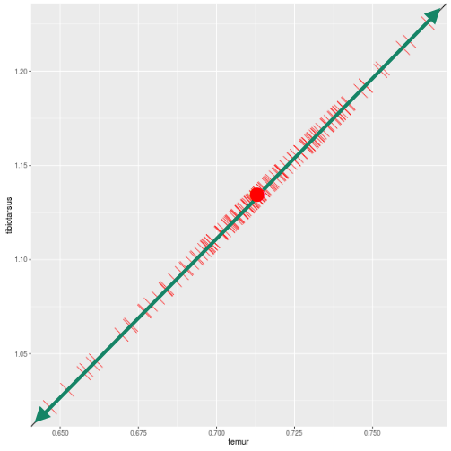

Correlation between:

Femur and score = 0.95

Tibiotarsus and score = 0.95

PC1 accounts for most of the variation in both

*Negative score, below the mean = little legs*

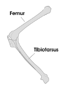

*Positive score, above the mean = big legs*

## Second component placed perpendicular to first

• *Negative slope through the data*

• *Positive correlation with femur (0.3)*

• *Negative correlation with tibiotarsus (-0.3)*

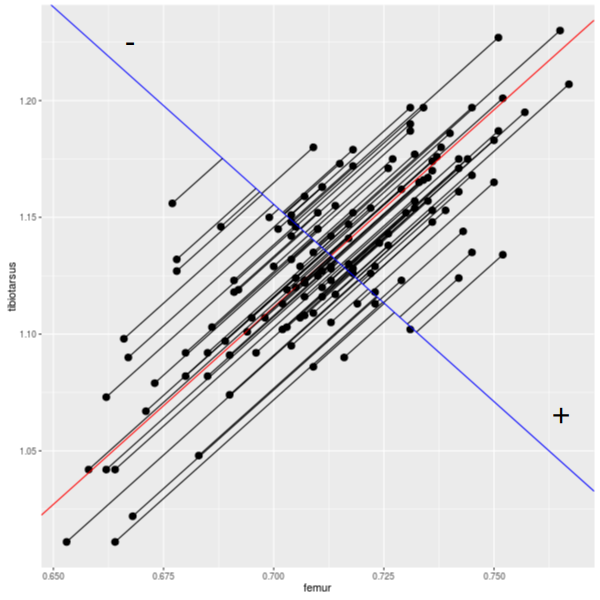

Variation not accounted for by PC1

## PC2 indicates leg shape

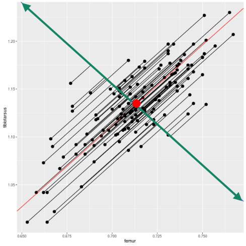

*Negative score, below the mean = long tib for femur*

*Positive score, above the mean = short tib for femur*

## PCA - data on new axes

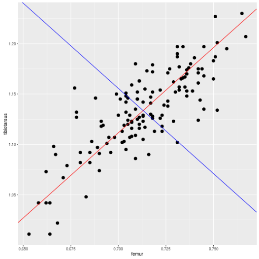

*Data - variables are correlated*

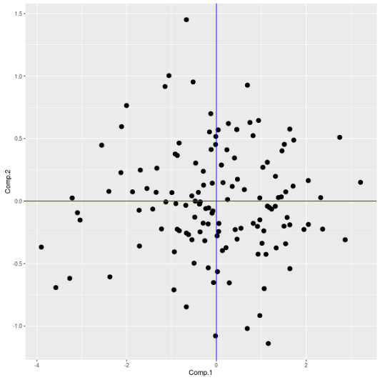

*PCA - axes are uncorrelated*

Small tib and femur

Large tib and femur

Large tibs for their femur size

Small tibs for their femur size

What about 3 variables?

# Doing the math

- The rules:
  - First axis maximizes variation along its length
  - Second axis is perpendicular to first, then maximizes variation in that direction
  - Proceed until as many axes as variables have been found
- Found using **Eigenanalysis** on a correlation or covariance matrix
  - Measures of explained variation = eigenvalues
  - PCA axes related to raw variables by coefficients, similar to slopes (eigenvectors)

## Start with a data set - Bumpus

| sex | age | survival | total length | alar extent | weight | len beak head | humerus | femur | tibiotarsus | skull width |
| --- | --- | --- | --- | --- | --- | --- | --- | --- | --- | --- |
| m | a | T | *154* | *241* | *24.5* | *31.2* | *0.687* | *0.668* | *1.022* | *0.587* |
| m | a | F | *165* | *240* | *26.5* | *31* | *0.738* | *0.704* | *1.095* | *0.606* |
| m | a | F | *160* | *245* | *26.1* | *32* | *0.736* | *0.709* | *1.109* | *0.611* |
| m | a | T | *160* | *252* | *26.9* | *30.8* | *0.736* | *0.709* | *1.18* | *0.602* |
| m | a | T | *155* | *243* | *26.9* | *30.6* | *0.733* | *0.704* | *1.151* | *0.602* |
| m | a | F | *161* | *249* | *25.6* | *32.3* | *0.743* | *0.718* | *1.128* | *0.602* |
| m | a | T | *154* | *245* | *24.3* | *31.7* | *0.741* | *0.688* | *1.146* | *0.584* |
| m | a | F | *162* | *246* | *25.9* | *32.3* | *0.738* | *0.709* | *1.135* | *0.607* |
| m | a | T | *156* | *247* | *24.1* | *31.5* | *0.715* | *0.706* | *1.129* | *0.575* |
| m | a | F | *163* | *250* | *25.5* | *32.5* | *0.752* | *0.731* | *1.197* | *0.623* |
| m | a | T | *161* | *253* | *26.5* | *31.8* | *0.78* | *0.743* | *1.144* | *0.607* |
| m | a | F | *162* | *247* | *27.6* | *31.8* | *0.731* | *0.719* | *1.113* | *0.597* |
| m | a | T | *157* | *251* | *24.6* | *31.1* | *0.741* | *0.736* | *1.153* | *0.610* |
| m | a | F | *163* | *246* | *25.8* | *31.4* | *0.689* | *0.662* | *1.073* | *0.604* |
| m | a | T | *159* | *247* | *24.2* | *31.4* | *0.728* | *0.718* | *1.126* | *0.609* |
| m | a | F | *161* | *246* | *24.9* | *30.5* | *0.739* | *0.726* | *1.138* | *0.580* |
| m | a | T | *158* | *247* | *23.6* | *29.8* | *0.703* | *0.673* | *1.079* | *0.602* |
| m | a | F | *160* | *242* | *26* | *31* | *0.745* | *0.713* | *1.105* | *0.600* |
| m | a | T | *158* | *252* | *26.2* | *32* | *0.749* | *0.739* | *1.153* | *0.614* |
| m | a | F | *162* | *246* | *26.5* | *31.5* | *0.72* | *0.696* | *1.092* | *0.606* |
| m | a | F | *160* | *249* | *26* | *31.4* | *0.726* | *0.689* | *1.097* | *0.602* |
| m | a | T | *160* | *252* | *26.2* | *32* | *0.741* | *0.723* | *1.129* | *0.624* |
| m | a | F | *161* | *250* | *27.1* | *31.6* | *0.737* | *0.711* | *1.12* | *0.631* |
| m | a | T | *162* | *253* | *24.8* | *32.3* | *0.766* | *0.752* | *1.134* | *0.633* |
| m | a | T | *161* | *243* | *25.4* | *31.8* | *0.721* | *0.722* | *1.126* | *0.597* |
| … | … | … | *…* | *…* | *…* | *…* | *…* | *…* | *…* | *…* |

## Correlation matrix

|  | total length | alar extent | weight | len beak head | humerus | femur | tibiotarsus | skull width | len keel |
| --- | --- | --- | --- | --- | --- | --- | --- | --- | --- |
| total length | 1.00 | 0.69 | 0.59 | 0.47 | 0.50 | 0.46 | 0.42 | 0.43 | 0.52 |
| alar extent | 0.69 | 1.00 | 0.57 | 0.50 | 0.67 | 0.58 | 0.52 | 0.42 | 0.58 |
| weight | 0.59 | 0.57 | 1.00 | 0.52 | 0.52 | 0.45 | 0.45 | 0.46 | 0.52 |
| len beak head | 0.47 | 0.50 | 0.52 | 1.00 | 0.62 | 0.61 | 0.58 | 0.53 | 0.50 |
| humerus | 0.50 | 0.67 | 0.52 | 0.62 | 1.00 | 0.81 | 0.73 | 0.51 | 0.55 |
| femur | 0.46 | 0.58 | 0.45 | 0.61 | 0.81 | 1.00 | 0.81 | 0.51 | 0.46 |
| tibiotarsus | 0.42 | 0.52 | 0.45 | 0.58 | 0.73 | 0.81 | 1.00 | 0.44 | 0.39 |
| skull width | 0.43 | 0.42 | 0.46 | 0.53 | 0.51 | 0.51 | 0.44 | 1.00 | 0.39 |
| len keel | 0.52 | 0.58 | 0.52 | 0.50 | 0.55 | 0.46 | 0.39 | 0.39 | 1.00 |

- Main diagonal = 1 for every variable, treated like their variances
- Weights all variables equally
- PCA will be dominated by correlations, not variances

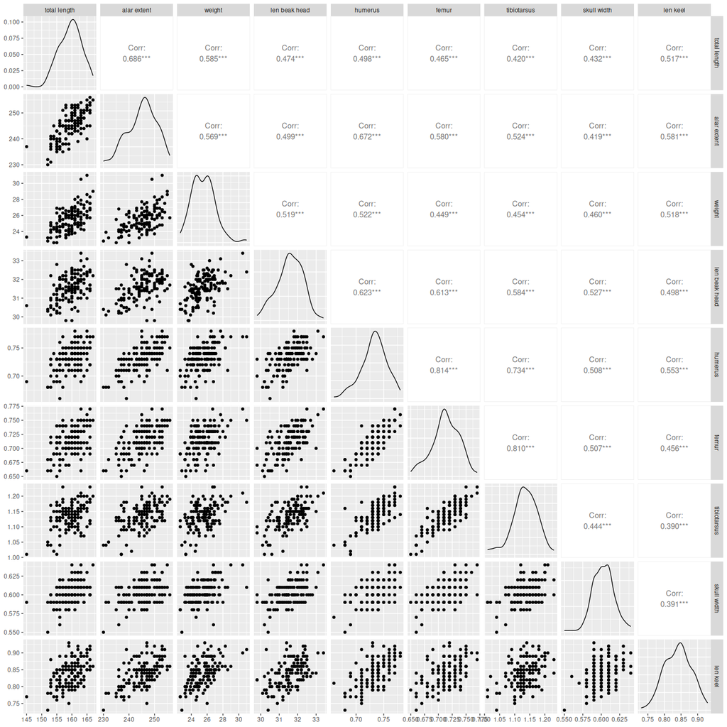

*Scatterplot matrix*

$\textbf{R}=\textbf{VLV}'$

Correlation matrix (**R**) as a matrix of coefficients (**V**, eigenvectors) and a matrix of scaling constants (**L**, eigenvalues)

$\textbf{L}=\textbf{V}'\textbf{RV}$

Factoring the correlation matrix

$\textbf{L}=$

| PC1 | PC2 | PC3 | PC4 | PC5 | PC6 | PC7 | PC8 | PC9 |
| --- | --- | --- | --- | --- | --- | --- | --- | --- |
| 5.32 | 0.00 | 0.00 | 0.00 | 0.00 | 0.0 | 0.0 | 0.00 | 0.00 |
| 0.00 | 0.97 | 0.00 | 0.00 | 0.00 | 0.0 | 0.0 | 0.00 | 0.00 |
| 0.00 | 0.00 | 0.67 | 0.00 | 0.00 | 0.0 | 0.0 | 0.00 | 0.00 |
| 0.00 | 0.00 | 0.00 | 0.53 | 0.00 | 0.0 | 0.0 | 0.00 | 0.00 |
| 0.00 | 0.00 | 0.00 | 0.00 | 0.46 | 0.0 | 0.0 | 0.00 | 0.00 |
| 0.00 | 0.00 | 0.00 | 0.00 | 0.00 | 0.4 | 0.0 | 0.00 | 0.00 |
| 0.00 | 0.00 | 0.00 | 0.00 | 0.00 | 0.0 | 0.3 | 0.00 | 0.00 |
| 0.00 | 0.00 | 0.00 | 0.00 | 0.00 | 0.0 | 0.0 | 0.21 | 0.00 |
| 0.00 | 0.00 | 0.00 | 0.00 | 0.00 | 0.0 | 0.0 | 0.00 | 0.15 |

*Eigenvalues*

$\textbf{V}=$

|  | PC 1 | PC 2 | PC 3 | PC 4 | PC 5 | PC 6 | PC 7 | PC 8 | PC 9 |
| --- | --- | --- | --- | --- | --- | --- | --- | --- | --- |
| length | -0.32 | -0.45 | -0.09 | 0.46 | 0.13 | 0.41 | 0.49 | 0.19 | -0.14 |
| alar | -0.35 | -0.26 | -0.33 | 0.22 | 0.27 | 0.04 | -0.64 | -0.36 | 0.19 |
| weight | -0.32 | -0.37 | 0.21 | 0.15 | -0.66 | -0.50 | -0.06 | 0.08 | 0.09 |
| head.len | -0.34 | 0.12 | 0.30 | -0.30 | -0.39 | 0.70 | -0.22 | -0.04 | 0.01 |
| humerus | -0.38 | 0.25 | -0.22 | -0.06 | 0.08 | -0.15 | -0.26 | 0.55 | -0.59 |
| femur | -0.36 | 0.42 | -0.15 | 0.05 | 0.07 | -0.06 | 0.18 | 0.33 | 0.72 |
| tibiotarsus | -0.34 | 0.45 | -0.17 | 0.15 | -0.16 | -0.12 | 0.34 | -0.63 | -0.27 |
| skull.wid | -0.29 | 0.05 | 0.78 | 0.06 | 0.50 | -0.18 | -0.01 | -0.08 | -0.04 |
| keel | -0.30 | -0.36 | -0.19 | -0.77 | 0.19 | -0.15 | 0.28 | -0.11 | 0.02 |

*Eigenvectors*

Each column is a PCA axis, as many as there are variables

## PCA output: eigenvalues

|  | PC1 | PC2 | PC3 | PC4 | PC5 | PC6 | PC7 | PC8 | PC9 |
| --- | --- | --- | --- | --- | --- | --- | --- | --- | --- |
| Eigenvalue | 5.318 | 0.965 | 0.668 | 0.525 | 0.464 | 0.399 | 0.296 | 0.214 | 0.152 |
| Proportion of variance | 0.591 | 0.107 | 0.074 | 0.058 | 0.052 | 0.044 | 0.033 | 0.024 | 0.017 |
| Cumulative proportion | 0.591 | 0.698 | 0.772 | 0.831 | 0.882 | 0.927 | 0.959 | 0.983 | 1.000 |

- Each eignvalue is variance in the data accounted for by a PCA axis
  - PC1 accounts for 5.33 variables-worth
  - PC2 drops below 1
  - Eigenvalues plotted from largest to smallest = scree plot, ➝

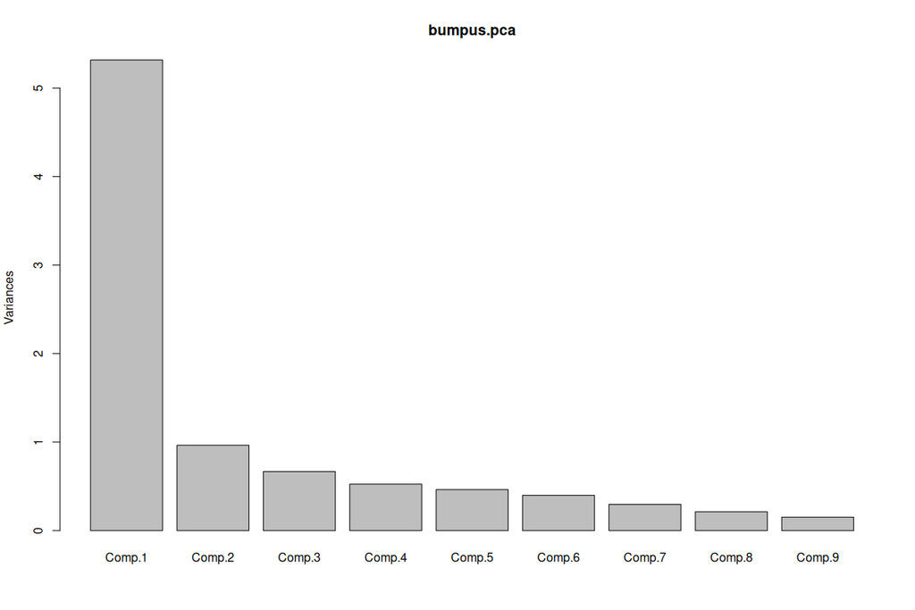

## PCA output - eigenvectors

|  | PC1 | PC2 | PC33 | PC4 | PC5 | PC6 | PC7 | PC8 | PC9 |
| --- | --- | --- | --- | --- | --- | --- | --- | --- | --- |
| length | 0.316 | 0.456 | 0.106 | 0.447 | 0.145 | 0.395 | 0.487 | 0.233 | 0.115 |
| alar | 0.348 | 0.262 | 0.344 | 0.198 | 0.273 | 0.051 | -0.617 | -0.416 | -0.148 |
| weight | 0.316 | 0.36 | -0.163 | 0.164 | -0.681 | -0.486 | -0.069 | 0.063 | -0.089 |
| head.len | 0.335 | -0.12 | -0.293 | -0.295 | -0.395 | 0.707 | -0.207 | -0.038 | -0.014 |
| humerus | 0.377 | -0.25 | 0.195 | -0.073 | 0.103 | -0.157 | -0.295 | 0.577 | 0.545 |
| femur | 0.363 | -0.422 | 0.154 | 0.056 | 0.078 | -0.069 | 0.148 | 0.28 | -0.743 |
| tibiotarsus | 0.341 | -0.461 | 0.176 | 0.14 | -0.152 | -0.108 | 0.377 | -0.581 | 0.326 |
| skull.wid | 0.29 | -0.042 | -0.805 | 0.114 | 0.456 | -0.187 | -0.024 | -0.095 | 0.031 |
| keel | 0.305 | 0.353 | 0.132 | -0.779 | 0.194 | -0.168 | 0.289 | -0.096 | -0.026 |

- Coefficients for linear combinations (like partial slopes)
  - Partial = after all other variables are accounted for
  - Define the lines through the data for each PC axis
- Used to calculate PCA **scores**

## Calculating scores

- PCA axes are linear **combinations** = variables multiplied by coefficients, added together
  - Use standardized variables = z-scores  
    $z=\frac{x_i-\bar{x}}{x}$
  - PCA 1 scores:  
    $s_{1,i}=\beta_1z_{1,i}+\beta_2z_{2,i}...+\beta_kz_{k,i}$
- Coefficients (β) are the eigenvectors for each axis
- Scores (s) are the position of each observation along a PC axis

*Sparrow #1*

|  | z-scores | PC1 | Product |
| --- | --- | --- | --- |
| total.length | -1.45 | 0.316 | -0.459 |
| alar.extent | -0.76 | 0.348 | -0.265 |
| weight | -0.69 | 0.316 | -0.219 |
| len.beak.head | -0.53 | 0.335 | -0.179 |
| humerus | -1.86 | 0.377 | -0.699 |
| femur | -1.77 | 0.363 | -0.643 |
| tibiotarsus | -2.75 | 0.341 | -0.937 |
| skull.width | -0.86 | 0.290 | -0.25 |
| len.keel | -0.26 | 0.305 | -0.08 |
|  |  | PC1 score: | -3.732 |

*Sparrow #2*

|  | z-scores | PC1 | Product |
| --- | --- | --- | --- |
| total.length | 1.47 | 0.316 | 0.465 |
| alar.extent | -0.94 | 0.348 | -0.328 |
| weight | 0.66 | 0.316 | 0.209 |
| len.beak.head | -0.82 | 0.335 | -0.274 |
| humerus | 0.32 | 0.377 | 0.121 |
| femur | -0.55 | 0.363 | -0.198 |
| tibiotarsus | -0.82 | 0.341 | -0.28 |
| skull.width | 0.48 | 0.290 | 0.139 |
| len.keel | 0.24 | 0.305 | 0.072 |
|  |  | PC1 score: | -0.075 |

# Reducing dimensionality

- The first PC axis is the biggest pattern in the data
- We can represent over half of the information in 9 variables with 1 PCA axis ➝ fewer dimensions
- This can make the results easier to interpret, focus our attention on the dominant patterns

## How many PC axes to retain?

- Want to retain enough to represent the data well
- Since axis eigenvalues get progressively smaller, deciding which to retain for interpretation is usually a **stopping rule**
  - Eigenvalues > 1 (Kaiser-Guttman rule)
  - Natural break on the scree plot
  - Retain as many as are needed to retain desired percentage of variation in the original data

## Eigenvalues and scree plot

|  | PC1 | PC2 | PC3 | PC4 | PC5 | PC6 | PC7 | PC8 | PC9 |
| --- | --- | --- | --- | --- | --- | --- | --- | --- | --- |
| Eigenvalue | 5.318 | 0.965 | 0.668 | 0.525 | 0.464 | 0.399 | 0.296 | 0.214 | 0.152 |
| Proportion of variance | 0.591 | 0.107 | 0.074 | 0.058 | 0.052 | 0.044 | 0.033 | 0.024 | 0.017 |
| Cumulative proportion | 0.591 | 0.698 | 0.772 | 0.831 | 0.882 | 0.927 | 0.959 | 0.983 | 1.000 |

- Kaiser-Guttman - stop after first axis
- Natural breaks - stop after first axis
- Consider keeping second because it is interpretable as size-independent shape
- Percent of variation - keeping first 2 retains 70% of variation in the data

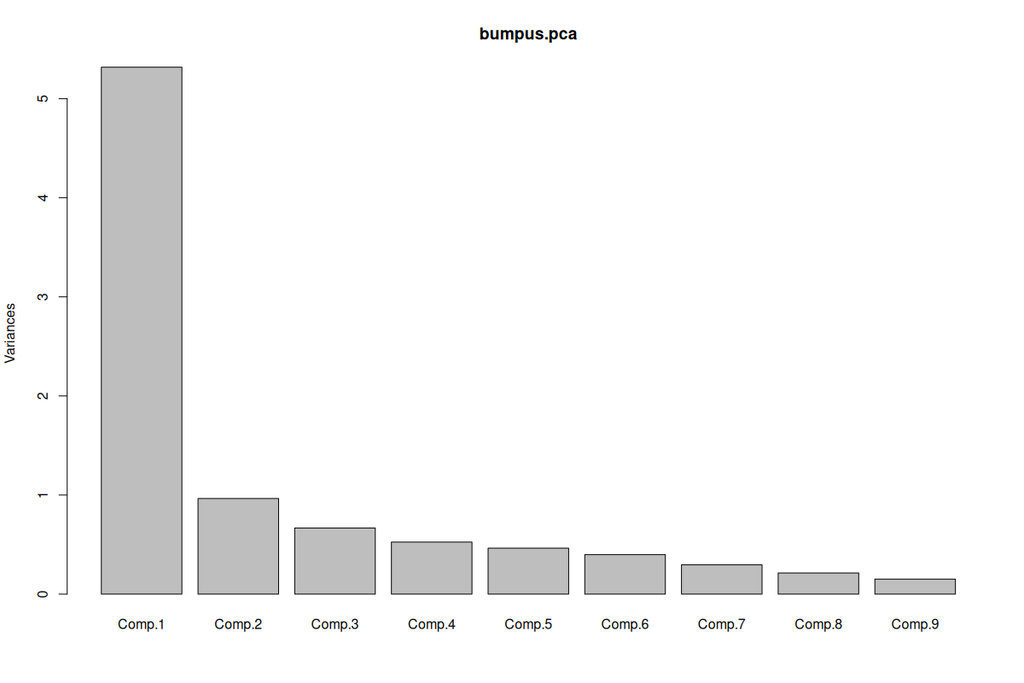

# Latent variables

- Treating axes as new variables, constructed from measured variables
  - Exist conceptually, but not measurable directly
- Goal: interpret axes as latent variables, and name them accordingly
- We base this on:
  - Which indicator variables are correlated with the axes
  - Signs of the correlations

## Naming the axes

- PC1:
  - Positive correlation with tib, femur
  - PC1 is size
- PC2:
  - Deviations from the size variation
  - PC2 is shape

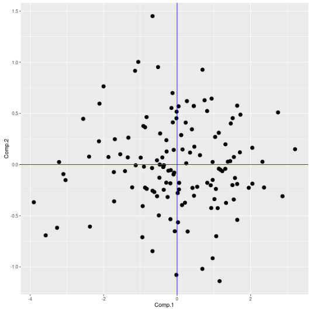

*Size*

Small tib and femur

Large tib and femur

Large tibs for their femur size

Small tibs for their femur size

*Shape*

Two leg variables example

## Interpreting axes: loadings

- Loadings = correlations between variables and PC axes (scores)
  - Help us interpret what axes tell us about structure
  - Help us name, interpret latent variables
- Differences from coefficients (eigenvectors)
  - *Not* partial relationships - bivariate relationship between each variable and each axis
- Sum of squared loadings is equal to the eigenvalue

## Terminology alert

- Sorry, but…
  - R calls coefficients loadings
  - Calls correlations between variables and axis scores structure **coefficients**
  - We will use coefficients for the eigenvectors, loadings for correlations

## Loadings for Bumpus PCA

|  | PC 1 | PC 2 | PC 3 | PC 4 | PC 5 | PC 6 | PC 7 | PC 8 | PC 9 |
| --- | --- | --- | --- | --- | --- | --- | --- | --- | --- |
| length | 0.73 | -0.45 | -0.07 | 0.33 | 0.09 | 0.26 | 0.26 | 0.09 | -0.05 |
| alar | 0.81 | -0.26 | -0.27 | 0.16 | 0.18 | 0.02 | -0.35 | -0.16 | 0.07 |
| weight | 0.73 | -0.36 | 0.17 | 0.11 | -0.44 | -0.32 | -0.03 | 0.04 | 0.04 |
| head.len | 0.77 | 0.12 | 0.24 | -0.22 | -0.27 | 0.44 | -0.12 | -0.02 | 0.00 |
| humerus | 0.87 | 0.25 | -0.18 | -0.04 | 0.05 | -0.10 | -0.14 | 0.25 | -0.23 |
| femur | 0.84 | 0.41 | -0.12 | 0.04 | 0.05 | -0.04 | 0.10 | 0.15 | 0.28 |
| tibiotarsus | 0.79 | 0.45 | -0.14 | 0.11 | -0.11 | -0.08 | 0.18 | -0.29 | -0.10 |
| skull.wid | 0.68 | 0.05 | 0.64 | 0.04 | 0.34 | -0.12 | -0.01 | -0.04 | -0.02 |
| keel | 0.70 | -0.36 | -0.15 | -0.56 | 0.13 | -0.09 | 0.15 | -0.05 | 0.01 |

- Magnitudes and sizes help interpret the axes
- Can graph on PCA axes in a **biplot**

## Point scores on PCA axes

- Numbers are case numbers (rows) from data set
- Cases plotted using scores on PC1 and PC2
- First two axes shown = largest fraction of the variance
  - Cases close together are similar on these axes
  - Cases far apart are different

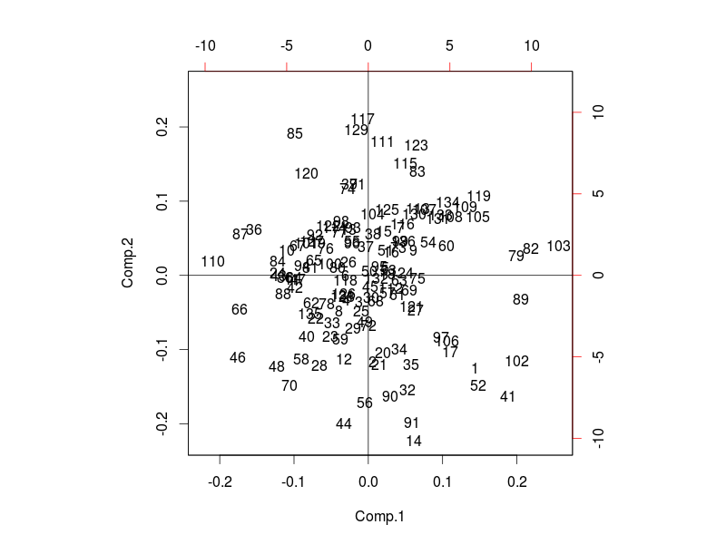

## Adding the variables = biplot

- Red vectors are variables
  - Extend in positive direction
  - Length indicates size of correlation
  - Vectors at right angles to an axis are independent of it
- All of the variables positively correlated with PC1
- Which variables are positively, negatively correlated with PC2?

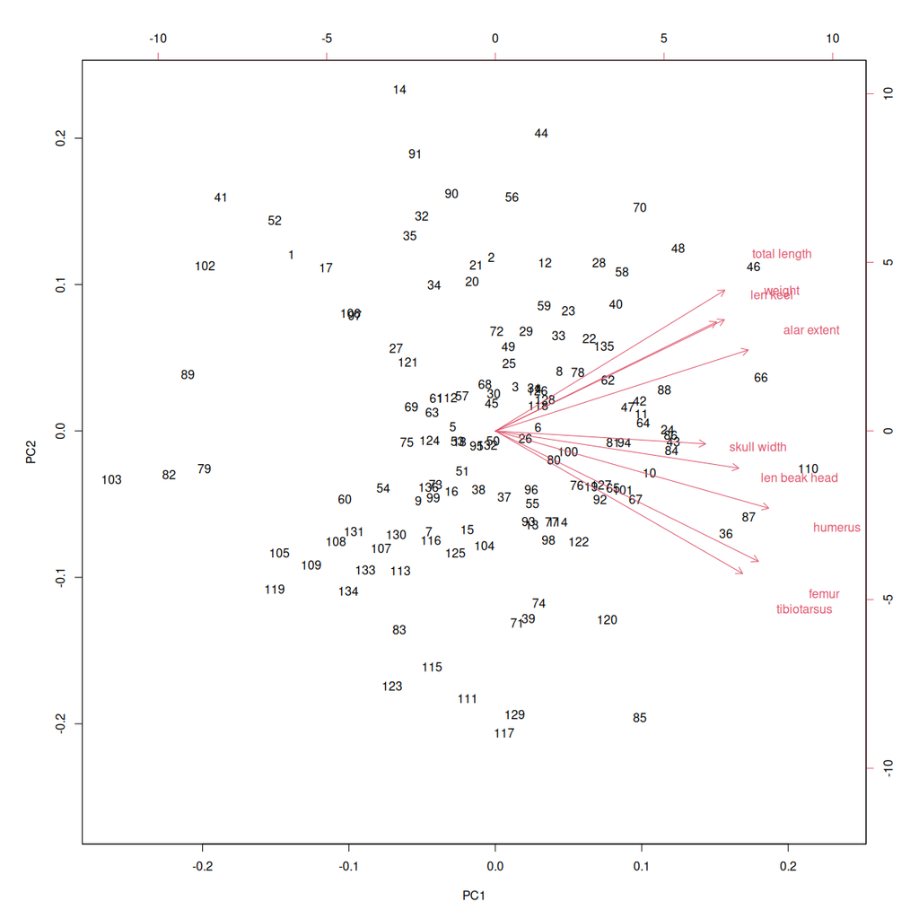

## Using the biplot to name the axes

- Why is PC1 size?
- Why is PC2 shape?

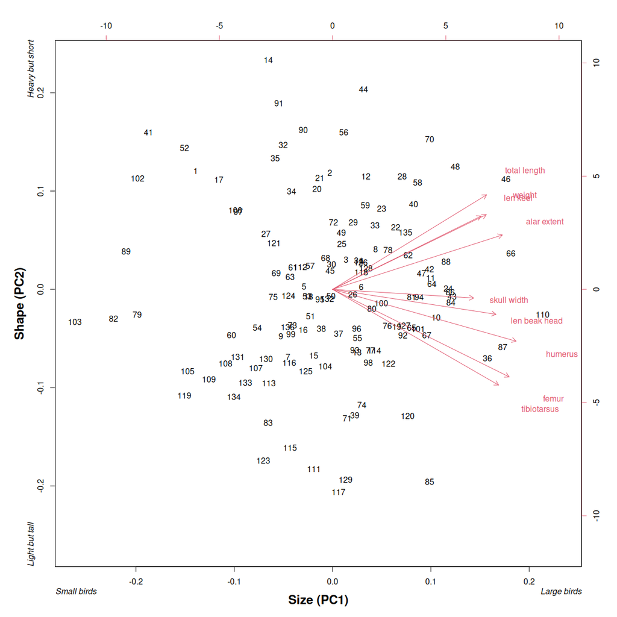

# Understanding structure

- Structure is any predictable variation in data
  - Correlations between numeric variables
  - Differences in mean
  - Different levels of random variation, autocorrelation, etc.
- PCA helps us understand structure across 2 or more numeric variables

## What to use to understand structure?

- Same as what we use to name latent variables
  - Loadings
  - Biplots
- But, use them to understand the multi-variable relationships
- Can also use **communalities** to tell us how much variation in the raw, indicator variables is associated with each PC axis

## Communalities

- Measures of how much variation each axis accounts for by variable
  - Squared loadings (correlations between axes and variables)
- Summed across retained axis = what is kept, what is lost for each variable

## Communalities for the Bumpus PCA

*Loadings (correlations between variables and PC axes)*

|  | PC 1 | PC 2 | PC 3 | PC 4 | PC 5 | PC 6 | PC 7 | PC 8 | PC 9 |
| --- | --- | --- | --- | --- | --- | --- | --- | --- | --- |
| length | -0.73 | -0.45 | -0.07 | 0.33 | 0.09 | 0.26 | 0.26 | 0.09 | -0.05 |
| alar | -0.81 | -0.26 | -0.27 | 0.16 | 0.18 | 0.02 | -0.35 | -0.16 | 0.07 |
| weight | -0.73 | -0.36 | 0.17 | 0.11 | -0.44 | -0.32 | -0.03 | 0.04 | 0.04 |
| head.len | -0.77 | 0.12 | 0.24 | -0.22 | -0.27 | 0.44 | -0.12 | -0.02 | 0.00 |
| humerus | -0.87 | 0.25 | -0.18 | -0.04 | 0.05 | -0.10 | -0.14 | 0.25 | -0.23 |
| femur | -0.84 | 0.41 | -0.12 | 0.04 | 0.05 | -0.04 | 0.10 | 0.15 | 0.28 |
| tibiotarsus | -0.79 | 0.45 | -0.14 | 0.11 | -0.11 | -0.08 | 0.18 | -0.29 | -0.10 |
| skull.wid | -0.68 | 0.05 | 0.64 | 0.04 | 0.34 | -0.12 | -0.01 | -0.04 | -0.02 |
| keel | -0.70 | -0.36 | -0.15 | -0.56 | 0.13 | -0.09 | 0.15 | -0.05 | 0.01 |

Square these to get…

*Squared correlations = communalities*

|  | PC 1 | PC 2 | PC 3 | PC 4 | PC 5 | PC 6 | PC 7 | PC 8 | PC 9 |
| --- | --- | --- | --- | --- | --- | --- | --- | --- | --- |
| length | 0.53 | 0.20 | 0.01 | 0.10 | 0.01 | 0.06 | 0.07 | 0.01 | 0.00 |
| alar | 0.65 | 0.07 | 0.08 | 0.02 | 0.03 | 0.00 | 0.11 | 0.04 | 0.00 |
| weight | 0.53 | 0.13 | 0.02 | 0.01 | 0.22 | 0.09 | 0.00 | 0.00 | 0.00 |
| head.len | 0.60 | 0.01 | 0.06 | 0.05 | 0.07 | 0.20 | 0.01 | 0.00 | 0.00 |
| humerus | 0.75 | 0.06 | 0.03 | 0.00 | 0.00 | 0.01 | 0.03 | 0.07 | 0.05 |
| femur | 0.70 | 0.17 | 0.02 | 0.00 | 0.00 | 0.00 | 0.01 | 0.02 | 0.08 |
| tibiotarsus | 0.62 | 0.21 | 0.02 | 0.01 | 0.01 | 0.00 | 0.04 | 0.07 | 0.02 |
| skull.wid | 0.45 | 0.00 | 0.43 | 0.01 | 0.10 | 0.01 | 0.00 | 0.00 | 0.00 |
| keel | 0.49 | 0.12 | 0.01 | 0.32 | 0.02 | 0.01 | 0.02 | 0.00 | 0.00 |

Take running totals to get…

*Cumulative communalities*

|  | First 2 | First 3 | First 4 | First 5 | First 6 | First 7 | First 8 | All 9 |
| --- | --- | --- | --- | --- | --- | --- | --- | --- |
| total | 0.73 | 0.74 | 0.84 | 0.85 | 0.92 | 0.99 | 1.00 | 1 |
| alar | 0.71 | 0.79 | 0.81 | 0.85 | 0.85 | 0.96 | 1.00 | 1 |
| weight | 0.66 | 0.67 | 0.69 | 0.90 | 1.00 | 1.00 | 1.00 | 1 |
| head.len | 0.61 | 0.67 | 0.72 | 0.79 | 0.99 | 1.00 | 1.00 | 1 |
| humerus | 0.81 | 0.84 | 0.84 | 0.85 | 0.86 | 0.88 | 0.95 | 1 |
| femur | 0.87 | 0.89 | 0.89 | 0.89 | 0.89 | 0.90 | 0.92 | 1 |
| tibiotarsus | 0.82 | 0.84 | 0.85 | 0.87 | 0.87 | 0.91 | 0.98 | 1 |
| skull.wid | 0.45 | 0.88 | 0.89 | 0.98 | 1.00 | 1.00 | 1.00 | 1 |
| keel | 0.61 | 0.63 | 0.94 | 0.96 | 0.97 | 1.00 | 1.00 | 1 |

Each column is proportion of variation explained for that row’s variable

# How do we know if the PCA is any good?

- No p-values - descriptive, not inferential
  - Want to retain fewest PC axes necessary
  - Discarding axes = discarding information, which can distort our understanding
  - What’s the best balance between simple and distorted?
- Rules of thumb:
  - Sample size and data structure requirements
  - Assumptions of the method
  - Guidelines based on comparisons with random data

## Enough of the appropriate data

*Rules of thumb based on:*

*Correlations*

- Correlation matrix: several r > 0.3
- Any number of r > 0.7 justify use of PCA

*N*

- n > 300 for any correlation matrix
- n > 150 if some large correlations

*Loadings*

- ≥ 4 loadings ≥ 0.6 - any n is okay
- ≥ 10 loadings ≥ 0.4 - okay if n ≥ 150
- With only low loadings need ≥ 300

## Assumptions

- Usual suspects
  - Random sampling, independent cases
  - Linearity, absence of outliers
- Components defined by sets of variables, not single ones
- Correlation matrix is factorable (we’ll let R worry about this one)

## Multivariate normality is routinely violated

- PCA can be used on any numeric data
- But, if the data are multivariate normal:
  - There are only linear relationships
  - Uncorrelated scores = the axes are independent
- If the data are not multivariate normal the scores will be uncorrelated, but there may be some non-linear relationships between components

## Should be better than random data

- NHST try to separate random from real effects
- No p-value in PCA, but can see what PCA on random data looks like
- Expect:
  - Correlation matrix will only have small r
  - Small eigenvalues
  - No natural breaks on the scree plot
- An example…

## Nine random variables, n = 136

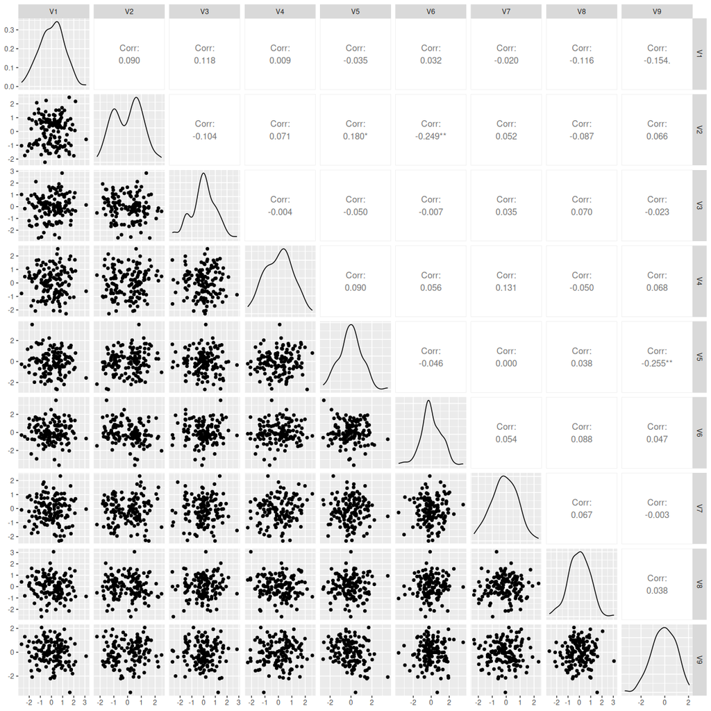

Not much reason to think PCA will find much

## PCA of random variables

| Axis | Eigenvalue |
| --- | --- |
| Comp.1 | 1.428 |
| Comp.2 | 1.239 |
| Comp.3 | 1.197 |
| Comp.4 | 1.136 |
| Comp.5 | 1.028 |
| Comp.6 | 0.880 |
| Comp.7 | 0.854 |
| Comp.8 | 0.707 |
| Comp.9 | 0.532 |

Only small eigenvalues

No natural breaks in the scree plot

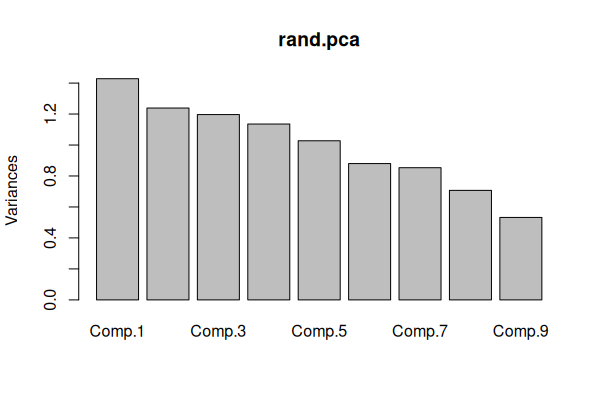

# PCA on a covariance matrix

- Identical math
- Some differences in interpretation:
  - Eigenvalues are no longer “number of variables accounted for” (so no Kaiser-Guttman rule)
  - Variables with large variances dominate, rather than groups of correlated variables
  - Results are affected by measurement units

## The covariance matrix

|  | length | alar | weight | head.len | humerus | femur | tibiotarsus | skull.wid | keel |
| --- | --- | --- | --- | --- | --- | --- | --- | --- | --- |
| length | 14.1468 | 14.2515 | 3.2483 | 1.2535 | 0.0431 | 0.0428 | 0.0655 | 0.0242 | 0.0778 |
| alar | 14.2515 | 30.4817 | 4.6315 | 1.9353 | 0.0853 | 0.0783 | 0.1201 | 0.0345 | 0.1283 |
| weight | 3.2483 | 4.6315 | 2.1763 | 0.5380 | 0.0177 | 0.0162 | 0.0278 | 0.0101 | 0.0305 |
| head.len | 1.2535 | 1.9353 | 0.5380 | 0.4933 | 0.0101 | 0.0105 | 0.0170 | 0.0055 | 0.0140 |
| humerus | 0.0431 | 0.0853 | 0.0177 | 0.0101 | 0.0005 | 0.0005 | 0.0007 | 0.0002 | 0.0005 |
| femur | 0.0428 | 0.0783 | 0.0162 | 0.0105 | 0.0005 | 0.0006 | 0.0008 | 0.0002 | 0.0004 |
| tibiotarsus | 0.0655 | 0.1201 | 0.0278 | 0.0170 | 0.0007 | 0.0008 | 0.0017 | 0.0003 | 0.0006 |
| skull.wid | 0.0242 | 0.0345 | 0.0101 | 0.0055 | 0.0002 | 0.0002 | 0.0003 | 0.0002 | 0.0002 |
| keel | 0.0778 | 0.1283 | 0.0305 | 0.0140 | 0.0005 | 0.0004 | 0.0006 | 0.0002 | 0.0016 |

## PCA with a covariance matrix - eigenvalues

|  | Comp.1 | Comp.2 | Comp.3 | Comp.4 | Comp.5 | Comp.6 | Comp.7 | Comp.8 | Comp.9 |
| --- | --- | --- | --- | --- | --- | --- | --- | --- | --- |
| Eigenvalues | 39.44 | 5.90 | 1.30 | 0.31 | 0 | 0 | 0 | 0 | 0 |
| Proportion of variance | 0.84 | 0.13 | 0.03 | 0.01 | 0 | 0 | 0 | 0 | 0 |
| Cumulative proportion | 0.84 | 0.97 | 0.99 | 1.00 | 1 | 1 | 1 | 1 | 1 |

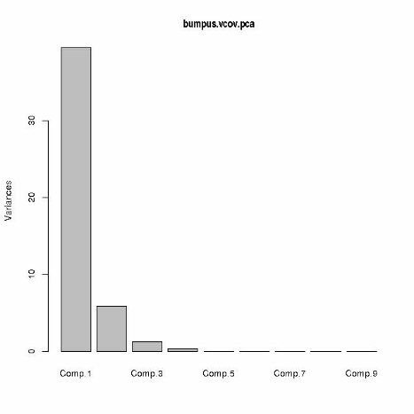

## Loadings

|  | Comp.1 | Comp.2 | Comp.3 | Comp.4 | Comp.5 | Comp.6 | Comp.7 | Comp.8 | Comp.9 |
| --- | --- | --- | --- | --- | --- | --- | --- | --- | --- |
| length | 0.83 | 0.55 | 0.05 | 0.00 | 0.00 | 0.00 | 0.00 | 0.00 | 0.00 |
| alar | 0.97 | -0.23 | 0.02 | 0.00 | 0.00 | 0.00 | 0.00 | 0.00 | 0.00 |
| weight | 0.64 | 0.17 | -0.75 | 0.07 | 0.00 | 0.00 | 0.00 | 0.00 | 0.00 |
| head.len | 0.54 | 0.08 | -0.29 | -0.79 | 0.00 | 0.00 | 0.00 | 0.00 | 0.00 |
| humerus | 0.67 | -0.09 | -0.17 | -0.28 | 0.42 | -0.11 | -0.37 | 0.15 | 0.29 |
| femur | 0.59 | -0.03 | -0.14 | -0.33 | 0.58 | -0.03 | -0.33 | 0.08 | -0.28 |
| tibiotarsus | 0.54 | -0.03 | -0.19 | -0.31 | 0.74 | 0.05 | 0.16 | -0.03 | 0.02 |
| skull.wid | 0.46 | 0.11 | -0.22 | -0.26 | 0.15 | -0.04 | -0.33 | -0.72 | 0.05 |
| keel | 0.61 | 0.04 | -0.18 | -0.15 | 0.03 | -0.76 | 0.04 | 0.00 | -0.01 |

- Which variable is best represented by PC1?
- Is PC1 still size? Is PC2 still shape?

## Cumulative communalities

|  | Comp.1 | Comp.2 | Comp.3 | Comp.4 | Comp.5 | Comp.6 | Comp.7 | Comp.8 | Comp.9 |
| --- | --- | --- | --- | --- | --- | --- | --- | --- | --- |
| length | 0.69 | 1.00 | 1.00 | 1.00 | 1.00 | 1.00 | 1.00 | 1.00 | 1 |
| alar | 0.95 | 1.00 | 1.00 | 1.00 | 1.00 | 1.00 | 1.00 | 1.00 | 1 |
| weight | 0.41 | 0.43 | 0.99 | 1.00 | 1.00 | 1.00 | 1.00 | 1.00 | 1 |
| head.len | 0.29 | 0.30 | 0.38 | 1.00 | 1.00 | 1.00 | 1.00 | 1.00 | 1 |
| humerus | 0.45 | 0.46 | 0.49 | 0.57 | 0.75 | 0.76 | 0.89 | 0.92 | 1 |
| femur | 0.35 | 0.35 | 0.37 | 0.48 | 0.81 | 0.81 | 0.92 | 0.92 | 1 |
| tibiotarsus | 0.29 | 0.29 | 0.32 | 0.42 | 0.97 | 0.97 | 1.00 | 1.00 | 1 |
| skull.wid | 0.21 | 0.22 | 0.27 | 0.34 | 0.36 | 0.37 | 0.47 | 1.00 | 1 |
| keel | 0.37 | 0.37 | 0.40 | 0.43 | 0.43 | 1.00 | 1.00 | 1.00 | 1 |

Are PC1 and PC2 really multivariate? Or are they dominated by 1 or 2 variables?

## Problem: units matter if covariance used

*Original, big lengths in mm*

|  | Mean | Variance | Units |
| --- | --- | --- | --- |
| length | 159.4632 | 14.1468 | mm |
| alar | 245.1912 | 30.4817 | mm |
| weight | 25.5250 | 2.1763 | g |
| head.len | 31.5743 | 0.4933 | mm |
| humerus | 0.7326 | 0.0005 | in |
| femur | 0.7134 | 0.0006 | in |
| tibiotarsus | 1.1341 | 0.0017 | in |
| skull.wid | 0.6029 | 0.0002 | in |
| keel | 0.8405 | 0.0016 | in |

*Big lengths in inches*

|  | Mean | Variance | Units |
| --- | --- | --- | --- |
| length.in | 6.2781 | 0.0219 | in |
| alar.in | 9.6532 | 0.0472 | in |
| weight | 25.5250 | 2.1763 | g |
| head.len | 31.5743 | 0.4933 | mm |
| humerus | 0.7326 | 0.0005 | in |
| femur | 0.7134 | 0.0006 | in |
| tibiotarsus | 1.1341 | 0.0017 | in |
| skull.wid | 0.6029 | 0.0002 | in |
| keel | 0.8405 | 0.0016 | in |

## Comparison of the two

Original - big lengths in mm

|  | Comp.1 | Comp.2 | Comp.3 | Comp.4 | Comp.5 | Comp.6 | Comp.7 | Comp.8 | Comp.9 |
| --- | --- | --- | --- | --- | --- | --- | --- | --- | --- |
| Eigenvalues | 39.44 | 5.90 | 1.30 | 0.31 | 0 | 0 | 0 | 0 | 0 |
| Proportion of variance | 0.84 | 0.13 | 0.03 | 0.01 | 0 | 0 | 0 | 0 | 0 |
| Cumulative proportion | 0.84 | 0.97 | 0.99 | 1.00 | 1 | 1 | 1 | 1 | 1 |

*Big lengths in inches*

|  | Comp.1 | Comp.2 | Comp.3 | Comp.4 | Comp.5 | Comp.6 | Comp.7 | Comp.8 | Comp.9 |
| --- | --- | --- | --- | --- | --- | --- | --- | --- | --- |
| Eigenvalue | 2.34 | 0.34 | 0.03 | 0.01 | 0 | 0 | 0 | 0 | 0 |
| Proportion of variance | 0.86 | 0.12 | 0.01 | 0.00 | 0 | 0 | 0 | 0 | 0 |
| Cumulative proportion | 0.86 | 0.98 | 1.00 | 1.00 | 1 | 1 | 1 | 1 | 1 |

Not a problem with correlations, because they are unitless

## Comparison of loadings

Inches

mm

|  | Comp.1 | Comp.2 | Comp.3 | Comp.4 | Comp.5 | Comp.6 | Comp.7 | Comp.8 | Comp.9 |
| --- | --- | --- | --- | --- | --- | --- | --- | --- | --- |
| length | 0.83 | 0.55 | 0.05 | 0.00 | 0.00 | 0.00 | 0.00 | 0.00 | 0.00 |
| alar | 0.97 | -0.23 | 0.02 | 0.00 | 0.00 | 0.00 | 0.00 | 0.00 | 0.00 |
| weight | 0.64 | 0.17 | -0.75 | 0.07 | 0.00 | 0.00 | 0.00 | 0.00 | 0.00 |
| head.len | 0.54 | 0.08 | -0.29 | -0.79 | 0.00 | 0.00 | 0.00 | 0.00 | 0.00 |
| humerus | 0.67 | -0.09 | -0.17 | -0.28 | 0.42 | -0.11 | -0.37 | 0.15 | 0.29 |
| femur | 0.59 | -0.03 | -0.14 | -0.33 | 0.58 | -0.03 | -0.33 | 0.08 | -0.28 |
| tibiotarsus | 0.54 | -0.03 | -0.19 | -0.31 | 0.74 | 0.05 | 0.16 | -0.03 | 0.02 |
| skull.wid | 0.46 | 0.11 | -0.22 | -0.26 | 0.15 | -0.04 | -0.33 | -0.72 | 0.05 |
| keel | 0.61 | 0.04 | -0.18 | -0.15 | 0.03 | -0.76 | 0.04 | 0.00 | -0.01 |

|  | Comp.1 | Comp.2 | Comp.3 | Comp.4 | Comp.5 | Comp.6 | Comp.7 | Comp.8 | Comp.9 |
| --- | --- | --- | --- | --- | --- | --- | --- | --- | --- |
| length.in | 0.61 | 0.15 | 0.53 | 0.57 | 0.00 | 0.01 | 0.00 | 0.00 | 0.00 |
| alar.in | 0.60 | 0.19 | 0.75 | -0.19 | -0.01 | 0.01 | 0.00 | 0.00 | 0.00 |
| weight | 0.99 | -0.11 | -0.01 | 0.00 | 0.00 | 0.00 | 0.00 | 0.00 | 0.00 |
| head.len | 0.61 | 0.79 | -0.03 | 0.00 | 0.00 | 0.00 | 0.00 | 0.00 | 0.00 |
| humerus | 0.57 | 0.36 | 0.32 | -0.13 | 0.41 | -0.11 | -0.37 | 0.15 | 0.29 |
| femur | 0.50 | 0.40 | 0.26 | -0.07 | 0.57 | -0.03 | -0.33 | 0.08 | -0.28 |
| tibiotarsus | 0.50 | 0.36 | 0.20 | -0.08 | 0.74 | 0.04 | 0.16 | -0.03 | 0.02 |
| skull.wid | 0.50 | 0.29 | 0.10 | 0.06 | 0.15 | -0.05 | -0.33 | -0.72 | 0.05 |
| keel | 0.55 | 0.22 | 0.29 | 0.01 | 0.01 | -0.75 | 0.04 | 0.00 | -0.01 |

# Application: Kauth-Thomas Transformation

- Biggest pattern is light to dark = brightness
- Want to know where healthy variation is = greenness
- Also, where soil moisture is high = wetness
- Can convert LandSat bands into latent variables for brightness, wetness, greenness using Kauth-Thomas transformation

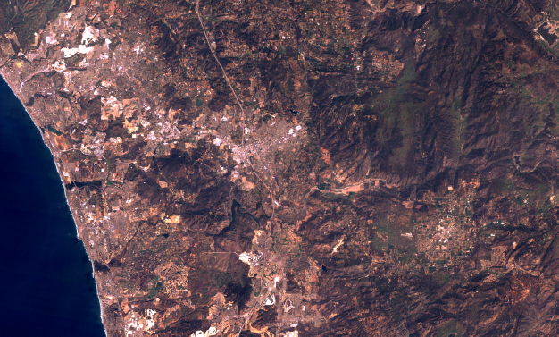

## The six bands used

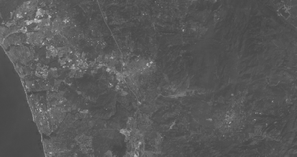

Band 1

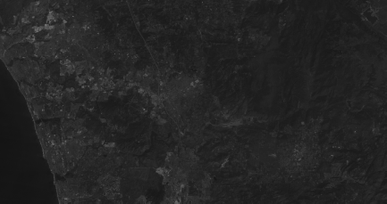

Band 2

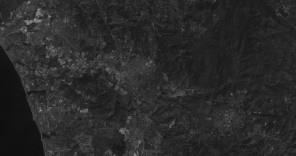

Band 3

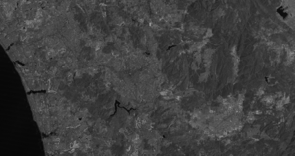

Band 4

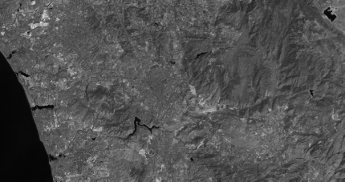

Band 5

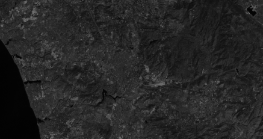

Band 6

## K-T transformation coefficients

Taken from a rotated PCA

| Component | Band 1 (Blue) | Band 2 (Green) | Band 3 (Red) | Band 4 (NIR) | Band 5 (SWIR1) | Band 7 (SWIR2) |
| --- | --- | --- | --- | --- | --- | --- |
| **Brightness** | 0.3037 | 0.2793 | 0.4743 | 0.5585 | 0.5082 | 0.1863 |
| **Greenness** | -0.2848 | -0.2435 | -0.5436 | 0.7243 | 0.0840 | -0.1800 |
| **Wetness** | 0.1509 | 0.1793 | 0.3299 | 0.3406 | -0.7112 | -0.4713 |

Developed from representative study areas, can be applied now to any image

## Coefficients applied to our scene

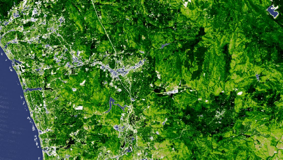

Greenness

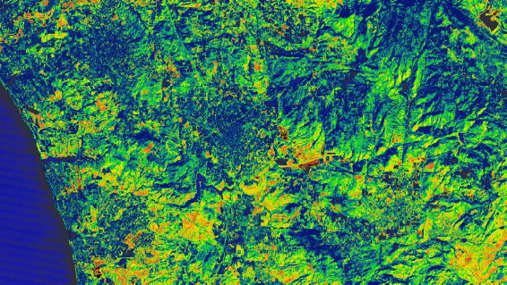

Wetness

Brightness is the first axis, accounts for the most variation, but is not the most important!

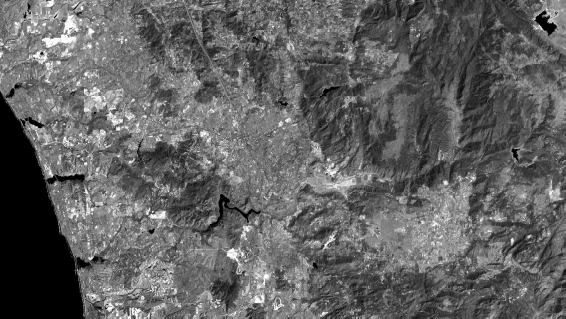

Brightness

Removing the effect of brightness allows greenness and wetness to be measured